# Prediction of Health Insurance Costs

Willy

24/2/2021

## Description

The topic of the dataset that I chose in this post is about predicting health insurance costs. The dataset that I took is from Kaggle. There are four algorithms that I use, including Simple Linear Regression, Polynomial Regression, Multiple Linear Regression and Multiple Linear Regression with Interaction. To get the dataset, please click [here.](https://www.kaggle.com/mirichoi0218/insurance)

**Report Outline**:  
1. Data Extraction  
2. Exploratory Data Analysis (EDA)  
3. Remove Outliers  
4. Modelling  
5. Evaluate the Model  
6. Recomendation

## Load the Libraries

The following are the packages that need to be installed:

```r
library(tidyverse)
library(psych)
library(ggridges)
library(broom.mixed)
library(viridis)
library(modelr)
library(lme4)
library(patchwork)
```

## 1. Data Extraction

This dataset is downloaded from Kaggle and saved in the data folder. We use **read.csv()** function to read the dataset and **insurance_df** as a data frame.

```r
insurance_df <-  read.csv("C:/Users/lenovo/Documents/theprojectmine/data/insurance.csv")
```

## 1.1. Check for Missing Values

This section is a check whether there is a missing value or not.

```r
insurance_df %>%
  summarise_all(
    ~ sum(is.na(.))
  )
```

```
##   age sex bmi children smoker region charges
## 1   0   0   0        0      0      0       0
```

## 1.2. Change Target to Factor

This section represents any of the factors that affect the cost of health insurance.

```r
insurance_df <- insurance_df %>%
  mutate(sex = factor(sex),
         smoker = factor(smoker),
         region = factor(region),
         children = factor(children)
  )
```

## 2. Exploratory Data Analysis

### 2.1. Charges Variables

In this section, it is a variable part of health insurance costs.

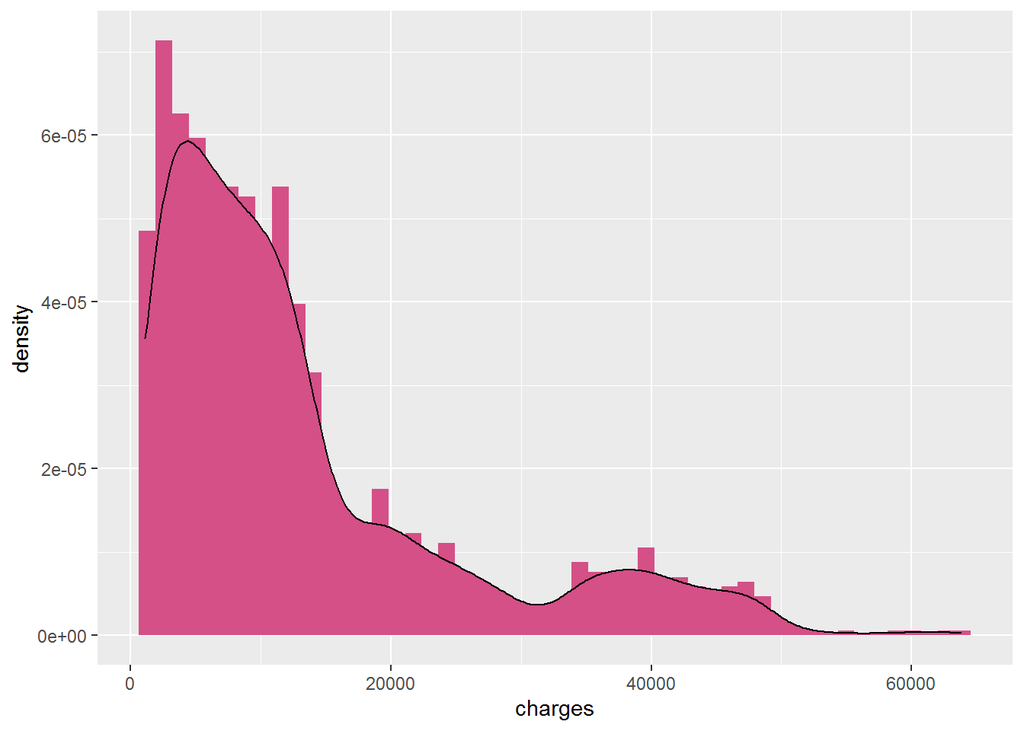

```r
insurance_df %>%
  ggplot(aes(charges, ..density.., fill = I("#d45087"))) +
  geom_histogram(bins = 50) +
  geom_density()+
  theme(legend.position = "none")
```

```r
tibble(low_charges = nrow(filter(insurance_df,charges<15000 )),
       middle_charges =  nrow(filter(insurance_df,charges>=15000 & charges<50000)),
       high_charges = nrow(filter(insurance_df, charges>=50000)),
)
```

```
## # A tibble: 1 x 3
##   low_charges middle_charges high_charges
##         <int>          <int>        <int>
## 1         980            351            7
```

### 2.2. Age Variables

In this section, it is a variable part of a person’s age.

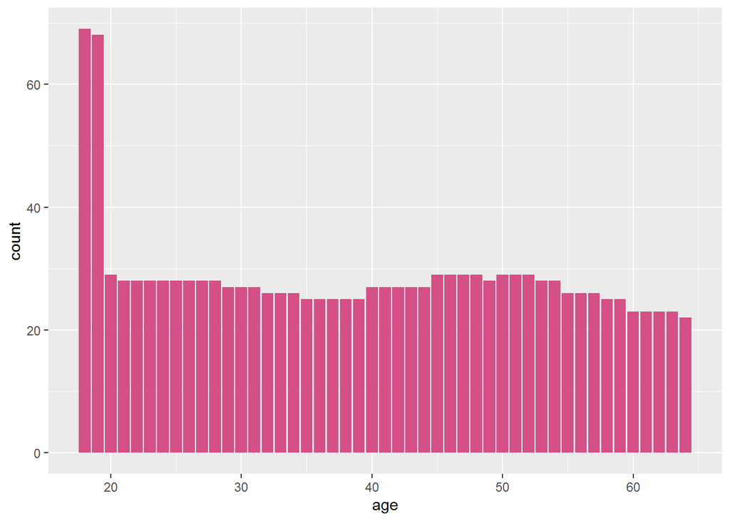

```r
insurance_df %>%
  ggplot(aes(age, fill = I("#d45087")))+
  geom_bar()+
  theme(legend.position = "none")
```

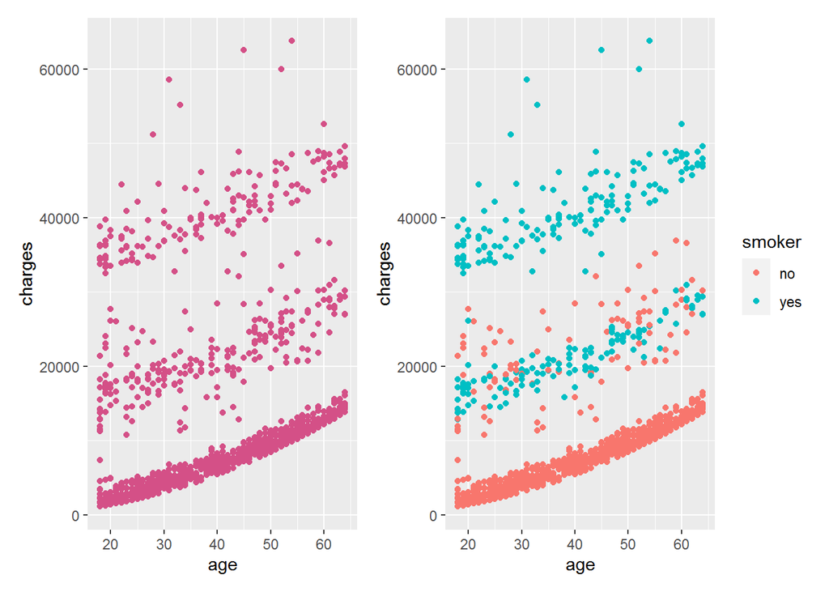

```r
p1 <- insurance_df %>%
  ggplot(aes(age, charges))+
  geom_point(color = I("#d45087"))

p2 <- insurance_df %>%
  ggplot(aes(age, charges, color = smoker))+
  geom_point()

p1+p2
```

### 2.3. Sex Variables

In this section, it is part of the gender variable.

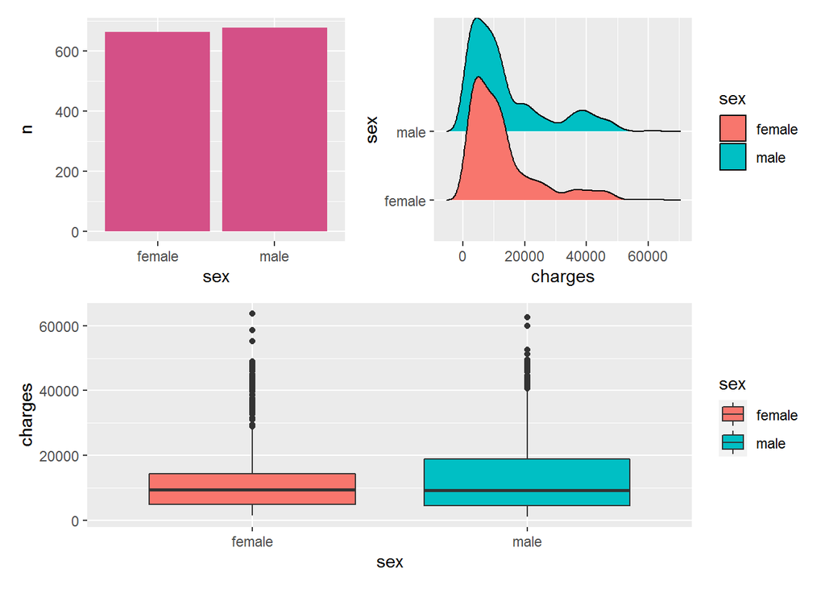

```r
p1 <- insurance_df %>%
  count(sex) %>%
  ggplot(aes(sex, n, fill = I("#d45087")))+
  geom_col()+
  theme(legend.position = "none")

p2 <- insurance_df %>%
  ggplot(aes(charges, sex, fill = sex)) +
  ggridges::geom_density_ridges()

p3 <- insurance_df %>%
  ggplot(aes(sex, charges, fill = sex))+
  geom_boxplot()

(p1+p2)/p3
```

### 2.4. BMI Variables

In this section, is the variable part of body weight.

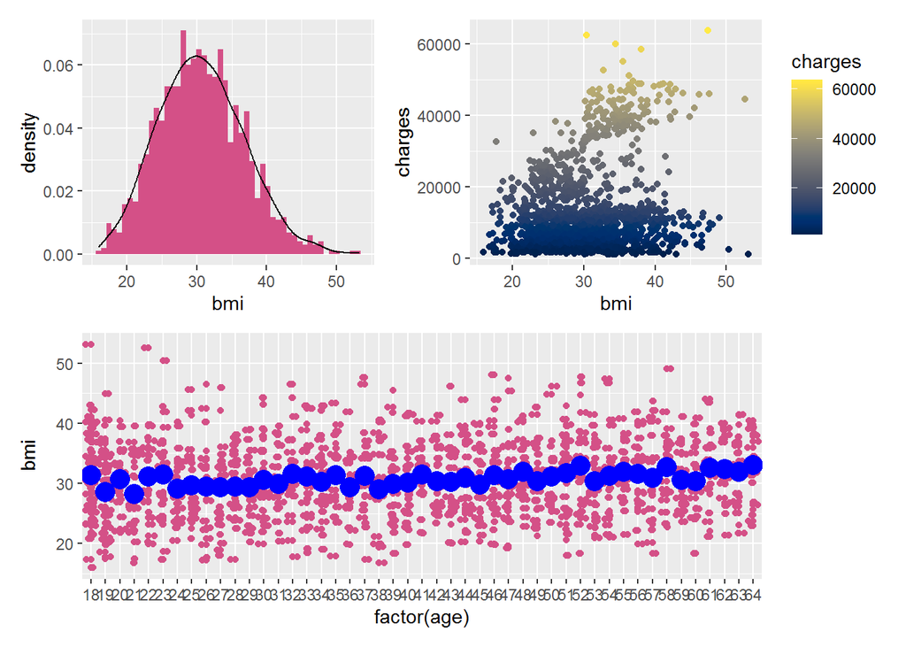

```r
p1 <- insurance_df %>%
  ggplot(aes(x = bmi, y = stat(density))) +
  geom_histogram( aes(fill = I("#d45087")), bins = 50) +
  theme(legend.position = "none") +
  geom_density()

p2 <- insurance_df %>%
  ggplot(aes(x = bmi, charges, color = charges)) +
  geom_point() +
  scale_color_viridis(option = "E")

p3 <- insurance_df %>%
  ggplot(aes(factor(age), bmi, color = I("#d45087"))) +
  geom_point() +
  geom_jitter() +
  stat_summary(fun = mean, colour = "blue", geom = "point", size = 5)

(p1+p2)/p3
```

### 2.5. The Number of Children

In this section, it is a variable part of the number of children of that person.

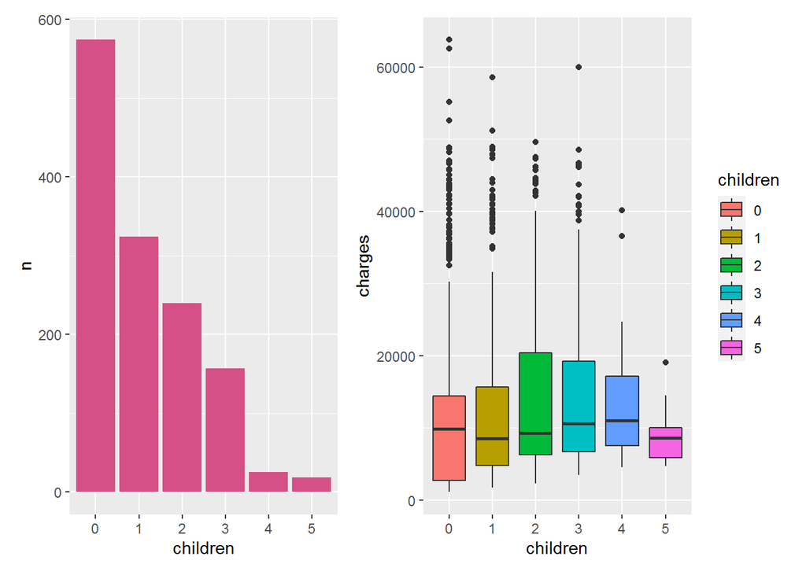

```r
p1 <- insurance_df %>%
  count(children) %>%
  ggplot(aes(children, n))+
  geom_col( aes(fill = I("#d45087")))+
  theme(legend.position = "none")

p2 <- insurance_df %>%
  ggplot(aes(children, charges, fill = children))+
  geom_boxplot()

p1+p2
```

### 2.6. Smoker Variables

In this section, it is a variable part of whether the person smokes or not.

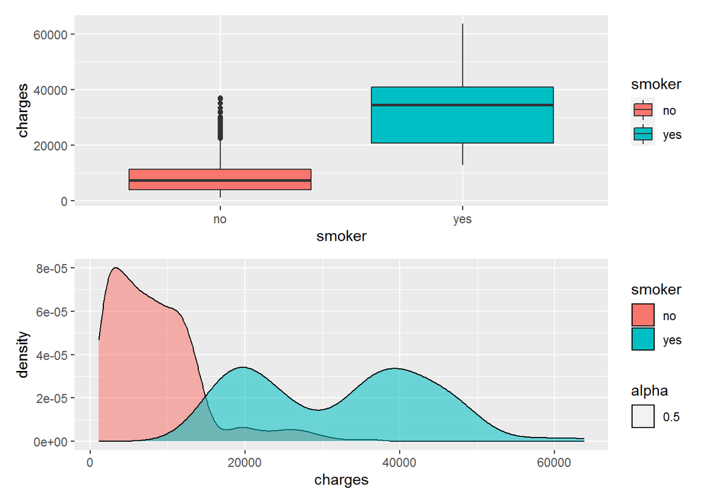

```r
p1 <- insurance_df %>%
  ggplot(aes(smoker,charges, fill = smoker))+
  geom_boxplot()

p2 <- insurance_df %>%
  ggplot(aes(charges, fill = smoker, alpha = 0.5))+
  geom_density()

p1/p2
```

### 2.7. Region Variables

In this section, it is a variable part based on where the person lives.

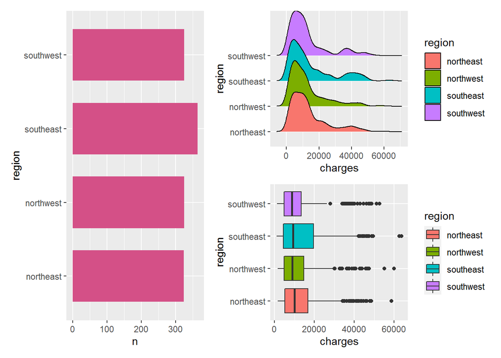

```r
p1 <- insurance_df %>%
  count(region) %>%
  ggplot(aes(region, n, width = 0.7, fill = I("#d45087")))+
  geom_col()+
  coord_flip()+
  theme(legend.position = "none")

p2 <- insurance_df %>%
  ggplot(aes(charges, region, fill = region)) +
  ggridges::geom_density_ridges()

p3 <- insurance_df %>%
  ggplot(aes(region, charges, fill = region))+
  geom_boxplot()+
  coord_flip()

p1+(p2/p3)
```

## 3. Remove Outliers

### 3.1. Get Outliers Values

In this section, it is a part of getting the outliers value.

```r
outliers_charges <- boxplot.stats(insurance_df$charges)$out
outliers_charges
```

```
##   [1] 39611.76 36837.47 37701.88 38711.00 35585.58 51194.56 39774.28 48173.36
##   [9] 38709.18 37742.58 47496.49 37165.16 39836.52 43578.94 47291.06 47055.53
##  [17] 39556.49 40720.55 36950.26 36149.48 48824.45 43753.34 37133.90 34779.61
##  [25] 38511.63 35160.13 47305.31 44260.75 41097.16 43921.18 36219.41 46151.12
##  [33] 42856.84 48549.18 47896.79 42112.24 38746.36 42124.52 34838.87 35491.64
##  [41] 42760.50 47928.03 48517.56 41919.10 36085.22 38126.25 42303.69 46889.26
##  [49] 46599.11 39125.33 37079.37 35147.53 48885.14 36197.70 38245.59 48675.52
##  [57] 63770.43 45863.21 39983.43 45702.02 58571.07 43943.88 39241.44 42969.85
##  [65] 40182.25 34617.84 42983.46 42560.43 40003.33 45710.21 46200.99 46130.53
##  [73] 40103.89 34806.47 40273.65 44400.41 40932.43 40419.02 36189.10 44585.46
##  [81] 43254.42 36307.80 38792.69 55135.40 43813.87 39597.41 36021.01 45008.96
##  [89] 37270.15 42111.66 40974.16 46113.51 46255.11 44202.65 48673.56 35069.37
##  [97] 39047.29 47462.89 38998.55 41999.52 41034.22 36580.28 35595.59 42211.14
## [105] 44423.80 37484.45 39725.52 44501.40 39727.61 48970.25 39871.70 34672.15
## [113] 41676.08 44641.20 41949.24 36124.57 38282.75 46661.44 40904.20 36898.73
## [121] 52590.83 40941.29 39722.75 37465.34 36910.61 38415.47 41661.60 60021.40
## [129] 47269.85 49577.66 37607.53 47403.88 38344.57 34828.65 62592.87 46718.16
## [137] 37829.72 36397.58 43896.38
```

### 3.2. Get Index of Outliers

In this section, it is part of getting the index from the outliers.

```r
outliers_ind <- which(insurance_df$charges %in% c(outliers_charges))
outliers_ind
```

```
##   [1]   15   20   24   30   31   35   39   40   50   54   56   83   85   87   95
##  [16]  110  124  147  159  162  176  186  204  224  241  243  252  253  255  257
##  [31]  264  266  272  282  289  293  299  313  315  323  328  329  331  339  374
##  [46]  378  382  421  422  423  442  477  489  501  525  531  544  550  559  570
##  [61]  578  588  610  616  622  624  630  666  668  669  675  678  683  690  698
##  [76]  707  726  737  739  740  743  760  804  820  827  829  843  846  851  853
##  [91]  857  861  884  894  902  918  948  952  954  957  959 1013 1022 1023 1032
## [106] 1037 1038 1048 1050 1063 1071 1079 1091 1097 1112 1118 1119 1123 1125 1140
## [121] 1147 1153 1157 1187 1207 1208 1219 1231 1241 1242 1250 1285 1289 1292 1301
## [136] 1302 1304 1314 1324
```

### 3.3. Data With Outliers

In this section, is the part using data with outliers.

```r
outliers_data <- insurance_df[outliers_ind, ]
insurance_df[outliers_ind, ]
```

```
##      age    sex    bmi children smoker    region  charges
## 15    27   male 42.130        0    yes southeast 39611.76
## 20    30   male 35.300        0    yes southwest 36837.47
## 24    34 female 31.920        1    yes northeast 37701.88
## 30    31   male 36.300        2    yes southwest 38711.00
## 31    22   male 35.600        0    yes southwest 35585.58
## 35    28   male 36.400        1    yes southwest 51194.56
## 39    35   male 36.670        1    yes northeast 39774.28
## 40    60   male 39.900        0    yes southwest 48173.36
## 50    36   male 35.200        1    yes southeast 38709.18
## 54    36   male 34.430        0    yes southeast 37742.58
## 56    58   male 36.955        2    yes northwest 47496.49
## 83    22   male 37.620        1    yes southeast 37165.16
## 85    37 female 34.800        2    yes southwest 39836.52
## 87    57 female 31.160        0    yes northwest 43578.94
```

[output cut: 125 more lines]

### 3.4. Data Without Outliers

In this section, it is a part of using data without outliers.

```r
insurance_df[-outliers_ind, ]
```

```
##      age    sex    bmi children smoker    region   charges
## 1     19 female 27.900        0    yes southwest 16884.924
## 2     18   male 33.770        1     no southeast  1725.552
## 3     28   male 33.000        3     no southeast  4449.462
## 4     33   male 22.705        0     no northwest 21984.471
## 5     32   male 28.880        0     no northwest  3866.855
## 6     31 female 25.740        0     no southeast  3756.622
## 7     46 female 33.440        1     no southeast  8240.590
## 8     37 female 27.740        3     no northwest  7281.506
## 9     37   male 29.830        2     no northeast  6406.411
## 10    60 female 25.840        0     no northwest 28923.137
## 11    25   male 26.220        0     no northeast  2721.321
## 12    62 female 26.290        0    yes southeast 27808.725
## 13    23   male 34.400        0     no southwest  1826.843
## 14    56 female 39.820        0     no southeast 11090.718
```

[output cut: 1185 more lines]

```r
insurance_df_no <- insurance_df[-outliers_ind,]
```

### 3.5 One Hot Encoder

In this section, it is one hot encoder.

```r
library(caret)
dmy = dummyVars(" ~ .", data = insurance_df_no[, -7])
encode_df = data.frame(predict(dmy, newdata = insurance_df_no[, -7]))
encode_df$charges <- insurance_df_no$charges
```

### 3.6. Divide Data Into Train and Test

This section is dividing the data into two, namely train and test.

```r
m <- nrow(insurance_df_no)
set.seed(2021)
train_idx <- sample(m, m * 0.8)

train_df <- insurance_df_no[train_idx, ]
test_df <- insurance_df_no[-train_idx, ]
```

## 4. Modelling

```r
fit.linreg <- lm(charges ~ smoker+age+bmi+children+region, data = train_df)
summary(fit.linreg)
```

```
##
## Call:
## lm(formula = charges ~ smoker + age + bmi + children + region,
##     data = train_df)
##
## Residuals:
##     Min      1Q  Median      3Q     Max
## -6196.0 -1856.5 -1193.6  -390.9 21922.8
##
## Coefficients:
##                 Estimate Std. Error t value Pr(>|t|)
## (Intercept)     -3455.56     912.73  -3.786 0.000163 ***
## smokeryes       14917.04     481.14  31.004  < 2e-16 ***
## age               241.26      10.66  22.640  < 2e-16 ***
## bmi                85.12      27.07   3.145 0.001714 **
## children1        -197.42     375.22  -0.526 0.598908
## children2        1453.84     418.99   3.470 0.000544 ***
## children3         827.46     504.07   1.642 0.101014
## children4        3134.25    1074.52   2.917 0.003619 **
## children5        1398.47    1170.68   1.195 0.232550
## regionnorthwest  -378.43     415.57  -0.911 0.362726
## regionsoutheast -1151.30     431.65  -2.667 0.007780 **
## regionsouthwest -1360.83     425.41  -3.199 0.001426 **
## ---
## Signif. codes:  0 '***' 0.001 '**' 0.01 '*' 0.05 '.' 0.1 ' ' 1
##
## Residual standard error: 4573 on 947 degrees of freedom
## Multiple R-squared:  0.6075, Adjusted R-squared:  0.603
## F-statistic: 133.3 on 11 and 947 DF,  p-value: < 2.2e-16
```

### 4.2. Polynomial Regression

This section uses Polynomial Regression.

```r
fit.polyreg <- lm(charges ~ smoker+age+bmi+children+region+I(age^2)+I(bmi^2), data = train_df)
summary(fit.polyreg)
```

```
##
## Call:
## lm(formula = charges ~ smoker + age + bmi + children + region +
##     I(age^2) + I(bmi^2), data = train_df)
##
## Residuals:
##    Min     1Q Median     3Q    Max
##  -5984  -1853  -1201   -447  22317
##
## Coefficients:
##                   Estimate Std. Error t value Pr(>|t|)
## (Intercept)     -7130.7735  3224.7873  -2.211 0.027258 *
## smokeryes       14973.7760   473.4647  31.626  < 2e-16 ***
## age              -123.1103    75.1928  -1.637 0.101909
## bmi               727.2366   193.6368   3.756 0.000183 ***
## children1         459.8136   391.5193   1.174 0.240517
## children2        2220.0514   437.3402   5.076 4.64e-07 ***
## children3        1424.0673   511.9458   2.782 0.005516 **
## children4        3565.2577  1064.3582   3.350 0.000841 ***
## children5        2321.3296  1161.7207   1.998 0.045983 *
## regionnorthwest  -401.1079   409.9513  -0.978 0.328113
## regionsoutheast -1095.3795   424.4253  -2.581 0.010005 *
## regionsouthwest -1345.4230   419.0518  -3.211 0.001369 **
## I(age^2)            4.6106     0.9439   4.885 1.22e-06 ***
## I(bmi^2)          -10.3748     3.0854  -3.363 0.000803 ***
## ---
## Signif. codes:  0 '***' 0.001 '**' 0.01 '*' 0.05 '.' 0.1 ' ' 1
##
## Residual standard error: 4495 on 945 degrees of freedom
## Multiple R-squared:  0.6216, Adjusted R-squared:  0.6163
## F-statistic: 119.4 on 13 and 945 DF,  p-value: < 2.2e-16
```

### 4.3. Multiple Linear Regression

This section uses Multiple Linear Regression.

```r
fit.multireg <- lm(formula = charges ~ ., data = train_df)
summary(fit.multireg)
```

```
##
## Call:
## lm(formula = charges ~ ., data = train_df)
##
## Residuals:
##     Min      1Q  Median      3Q     Max
## -6435.1 -1879.0 -1157.8  -403.1 21692.0
##
## Coefficients:
##                 Estimate Std. Error t value Pr(>|t|)
## (Intercept)     -3239.26     922.52  -3.511 0.000467 ***
## age               241.23      10.65  22.655  < 2e-16 ***
## sexmale          -461.20     295.60  -1.560 0.119041
## bmi                85.35      27.05   3.156 0.001652 **
## children1        -204.00     374.96  -0.544 0.586527
## children2        1455.00     418.68   3.475 0.000534 ***
## children3         823.64     503.70   1.635 0.102344
## children4        3199.53    1074.52   2.978 0.002979 **
## children5        1432.13    1169.99   1.224 0.221236
## smokeryes       14935.48     480.92  31.056  < 2e-16 ***
## regionnorthwest  -374.42     415.26  -0.902 0.367471
## regionsoutheast -1141.45     431.37  -2.646 0.008278 **
## regionsouthwest -1362.40     425.09  -3.205 0.001396 **
## ---
## Signif. codes:  0 '***' 0.001 '**' 0.01 '*' 0.05 '.' 0.1 ' ' 1
##
## Residual standard error: 4569 on 946 degrees of freedom
## Multiple R-squared:  0.6085, Adjusted R-squared:  0.6036
## F-statistic: 122.5 on 12 and 946 DF,  p-value: < 2.2e-16
```

### 4.4. Multiple Linear Regression with Interaction

This section uses Multiple Linear Regression with Interaction.

```r
fit.inmultireg <- lm(charges ~ smoker+age+bmi+children+region+I(age^2)+I(bmi^2)+age:bmi, data = train_df)
summary(fit.inmultireg)
```

```
##
## Call:
## lm(formula = charges ~ smoker + age + bmi + children + region +
##     I(age^2) + I(bmi^2) + age:bmi, data = train_df)
##
## Residuals:
##     Min      1Q  Median      3Q     Max
## -5875.7 -1851.0 -1163.4  -456.1 22372.6
##
## Coefficients:
##                   Estimate Std. Error t value Pr(>|t|)
## (Intercept)     -7571.3264  3484.3863  -2.173 0.030034 *
## smokeryes       14971.4835   473.7368  31.603  < 2e-16 ***
## age              -107.4752    88.5474  -1.214 0.225143
## bmi               736.2448   195.5878   3.764 0.000177 ***
## children1         462.3005   391.7738   1.180 0.238290
## children2        2225.2105   437.8171   5.083 4.49e-07 ***
## children3        1427.4495   512.2862   2.786 0.005436 **
## children4        3568.1893  1064.8946   3.351 0.000838 ***
## children5        2317.1041  1162.3354   1.993 0.046495 *
## regionnorthwest  -405.6619   410.3696  -0.989 0.323147
## regionsoutheast -1103.1741   425.2628  -2.594 0.009631 **
## regionsouthwest -1342.1783   419.3609  -3.201 0.001418 **
## I(age^2)            4.6458     0.9501   4.890 1.19e-06 ***
## I(bmi^2)          -10.1378     3.1670  -3.201 0.001415 **
## age:bmi            -0.6101     1.8226  -0.335 0.737880
## ---
## Signif. codes:  0 '***' 0.001 '**' 0.01 '*' 0.05 '.' 0.1 ' ' 1
##
## Residual standard error: 4497 on 944 degrees of freedom
## Multiple R-squared:  0.6216, Adjusted R-squared:  0.616
## F-statistic: 110.8 on 14 and 944 DF,  p-value: < 2.2e-16
```

## 5. Evaluate the Model

This section evaluates the computational results of several types of regression models.

```r
performance = function(test_df, model, model_name) {

  pred <- predict(model, test_df)
  error <- pred - test_df$charges
  mse <- mean(error ^ 2)
  rmse <- sqrt(mse)

  result <- paste("RMSE of", model_name, ":",
                  round(rmse, 2))
  result
}

performance(test_df, fit.linreg, "Simple Linear Regression")
```

```
## [1] "RMSE of Simple Linear Regression : 4597.67"
```

```r
performance(test_df, fit.polyreg, "Polynomial Regression")
```

```
## [1] "RMSE of Polynomial Regression : 4476.75"
```

```r
performance(test_df, fit.multireg, "Multiple Linear Regression")
```

```
## [1] "RMSE of Multiple Linear Regression : 4604.69"
```

```r
performance(test_df, fit.inmultireg, "MLR with Interaction")
```

```
## [1] "RMSE of MLR with Interaction : 4478.03"
```

```r
fit.inmultireg <- lm(charges ~ smoker+age+bmi+children+region+I(age^2)+I(bmi^2)+age:bmi, data = train_df)
summary(fit.inmultireg)
```

```
##
## Call:
## lm(formula = charges ~ smoker + age + bmi + children + region +
##     I(age^2) + I(bmi^2) + age:bmi, data = train_df)
##
## Residuals:
##     Min      1Q  Median      3Q     Max
## -5875.7 -1851.0 -1163.4  -456.1 22372.6
##
## Coefficients:
##                   Estimate Std. Error t value Pr(>|t|)
## (Intercept)     -7571.3264  3484.3863  -2.173 0.030034 *
## smokeryes       14971.4835   473.7368  31.603  < 2e-16 ***
## age              -107.4752    88.5474  -1.214 0.225143
## bmi               736.2448   195.5878   3.764 0.000177 ***
## children1         462.3005   391.7738   1.180 0.238290
## children2        2225.2105   437.8171   5.083 4.49e-07 ***
## children3        1427.4495   512.2862   2.786 0.005436 **
## children4        3568.1893  1064.8946   3.351 0.000838 ***
## children5        2317.1041  1162.3354   1.993 0.046495 *
## regionnorthwest  -405.6619   410.3696  -0.989 0.323147
## regionsoutheast -1103.1741   425.2628  -2.594 0.009631 **
## regionsouthwest -1342.1783   419.3609  -3.201 0.001418 **
## I(age^2)            4.6458     0.9501   4.890 1.19e-06 ***
## I(bmi^2)          -10.1378     3.1670  -3.201 0.001415 **
## age:bmi            -0.6101     1.8226  -0.335 0.737880
## ---
## Signif. codes:  0 '***' 0.001 '**' 0.01 '*' 0.05 '.' 0.1 ' ' 1
##
## Residual standard error: 4497 on 944 degrees of freedom
## Multiple R-squared:  0.6216, Adjusted R-squared:  0.616
## F-statistic: 110.8 on 14 and 944 DF,  p-value: < 2.2e-16
```